# Visualização de Dados com `ggplot2`

Marcus Nunes

17 e 18 de Maio de 2018

# Introdução

## Introdução

- `ggplot2` é um pacote de visualização de dados
- Foi criado por Hadley Wickham em 2007, baseado no livro *Grammar of Graphics*, de Leland Wilkinson
- A ideia principal é criar gráficos como se eles fossem frases de uma língua, onde casa elemento do gráfico é uma palavra

## Introdução

- Por exemplo, veja o gráfico do próximo slide
- Este gráfico foi criado com muito pouco código utilizando `ggplot2`
- Como seria possível criá-lo utilizando as ferramentas tradicionais do `R`?

## Introdução

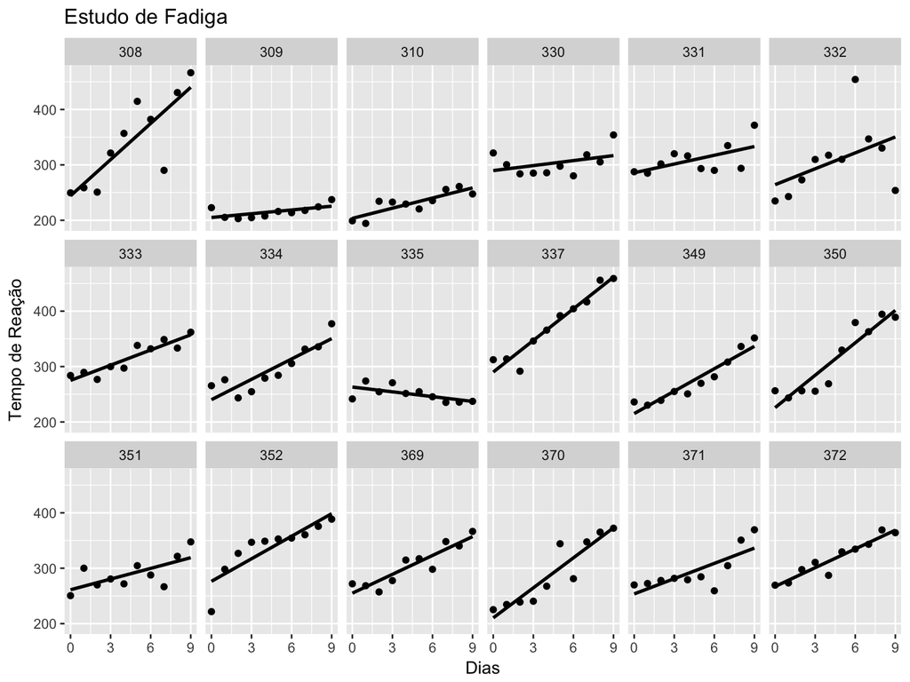

# Sintaxe Básica

## Sintaxe Básica

- O `ggplot2` exige que os dados a serem plotados estejam em um data frame
- Não é possível plotar diretamente os dados presentes em uma matriz ou um vetor
- **Sempre** teremos que transformar os dados para data frame ou construir um data frame com os dados que possuímos

## Sintaxe Básica

- Trabalharemos com o conjunto de dados `sleepstudy`, do pacote `lme4`
- Carregue este arquivo na memória do `R` através do comando

```r
library(lme4)
```

## Sintaxe Básica

- Verifique se está tudo correto através dos comandos

```r
str(sleepstudy)
```

```
## 'data.frame':    180 obs. of  3 variables:
##  $ Reaction: num  250 259 251 321 357 ...
##  $ Days    : num  0 1 2 3 4 5 6 7 8 9 ...
##  $ Subject : Factor w/ 18 levels "308","309","310",..: 1 1 1 1 1 1 1 1 1 1 ...
```

```r
head(sleepstudy)
```

```
##   Reaction Days Subject
## 1 249.5600    0     308
## 2 258.7047    1     308
## 3 250.8006    2     308
## 4 321.4398    3     308
## 5 356.8519    4     308
## 6 414.6901    5     308
```

## Sintaxe Básica

- Este conjunto de dados reporta o tempo médio de reação (`Reaction`) de 18 voluntários após um certo número de dias (`Days`) em que eles dormiram 3 horas por noite
- Queremos fazer a análise exploratória deste conjunto de dados
- O objetivo ao final é que consigamos entender como construir o gráfico que vimos alguns slides atrás

## Sintaxe Básica - Gráfico de Dispersão

- O comando principal a ser utilizado se chama `ggplot`
- Através dele vamos definir qual é a variável preditora e qual é a variável resposta em nosso conjunto de dados

## Sintaxe Básica - Gráfico de Dispersão

## Sintaxe Básica - Gráfico de Dispersão

## Sintaxe Básica - Gráfico de Dispersão

## Sintaxe Básica - Gráfico de Dispersão

## Sintaxe Básica - Gráfico de Dispersão

## Sintaxe Básica - Gráfico de Dispersão

## Sintaxe Básica - Gráfico de Dispersão

## Sintaxe Básica - Gráfico de Dispersão

## Sintaxe Básica - Gráfico de Dispersão

## Sintaxe Básica - Gráfico de Dispersão

## Sintaxe Básica

## Sintaxe Básica

## Sintaxe Básica

## Sintaxe Básica